# London Bikes Analytics

Isabella Madiedo Soto

2025-01-13

# 1 Library Load

```r
library(tidyverse)
library(dplyr)
library(ggplot2)
library(htmlwidgets)
library(leaflet)
library(mosaic)
library(scales)
```

# 2 Data Load

This study leverages data from http://www.tfl.gov.uk to analyse London’s Bike Sharing System. The objective is to identify and understand significant data patterns which can provide useful insight for the design and characteristics of the sharing system currently in place.

```
## # A tibble: 5 × 20
##   Day        bikes_hired  year month  date day_of_week season avg_temp
##   <date>           <dbl> <dbl> <dbl> <dbl> <chr>       <chr>     <dbl>
## 1 2011-01-01        4555  2011     1     1 Saturday    1             6
## 2 2011-01-02        6250  2011     1     2 Sunday      1             3
## 3 2011-01-03        7262  2011     1     3 Monday      1             0
## 4 2011-01-04       13430  2011     1     4 Tuesday     1             3
## 5 2011-01-05       13757  2011     1     5 Wednesday   1             6
## # ℹ 12 more variables: avg_humidity <dbl>, avg_pressure <dbl>,
## #   avg_windspeed <dbl>, rainfall_mm <dbl>, Rain <dbl>, Fog <dbl>,
## #   Thunderstorm <dbl>, Snow <dbl>, rain <lgl>, fog <lgl>, thunderstorm <lgl>,
## #   snow <lgl>
```

## 2.1 Data Preprocessing

### 2.1.1 Date format

Firstly, in order to maintain consistency across date formats, we use lubridate’s `ymd` function to for the variable `Day` to be in the format *YYYY-MM-DD*

```r
bike_data <- bike_data %>%
  mutate(
    Day=ymd(Day))
```

### 2.1.2 Day of the Week

Secondly we relevel the variable `day_of_week` as an ordered factor from its existing `chr` type. This step identifies the ordered days of the week (starting with Monday) and allows factor treatment.

```r
bike_data <- bike_data %>%
  mutate(
    day_of_week = fct_relevel(day_of_week, "Monday", "Tuesday", "Wednesday", "Thursday", "Friday", "Saturday", "Sunday"))
```

### 2.1.3 Season

Thirdly, for increased clarity we update the `season` variable from *1, 2, 3, 4* to *Winter*, *Spring*, *Summer* and *Autumn*

```r
bike_data <- bike_data %>%
  mutate(
    season = case_when(
      season == 1 ~ "Winter",
      season == 2 ~ "Spring",
      season == 3 ~ "Summer",
      season == 4 ~ "Autumn"
    ),
    season = fct_relevel(season, "Winter", "Spring", "Summer", "Autumn")
  )
```

### 2.1.4 Updated Dataset

Laslty, we visualise the data to ensure the changes listed above have been incorporated correctly.

```r
head(bike_data, n=5)
```

```
## # A tibble: 5 × 20
##   Day        bikes_hired  year month  date day_of_week season avg_temp
##   <date>           <dbl> <dbl> <dbl> <dbl> <fct>       <fct>     <dbl>
## 1 2011-01-01        4555  2011     1     1 Saturday    Winter        6
## 2 2011-01-02        6250  2011     1     2 Sunday      Winter        3
## 3 2011-01-03        7262  2011     1     3 Monday      Winter        0
## 4 2011-01-04       13430  2011     1     4 Tuesday     Winter        3
## 5 2011-01-05       13757  2011     1     5 Wednesday   Winter        6
## # ℹ 12 more variables: avg_humidity <dbl>, avg_pressure <dbl>,
## #   avg_windspeed <dbl>, rainfall_mm <dbl>, Rain <dbl>, Fog <dbl>,
## #   Thunderstorm <dbl>, Snow <dbl>, rain <lgl>, fog <lgl>, thunderstorm <lgl>,
## #   snow <lgl>
```

# 3 Exploratory Data Analysis

## 3.1 Time Series: Bikes Hired

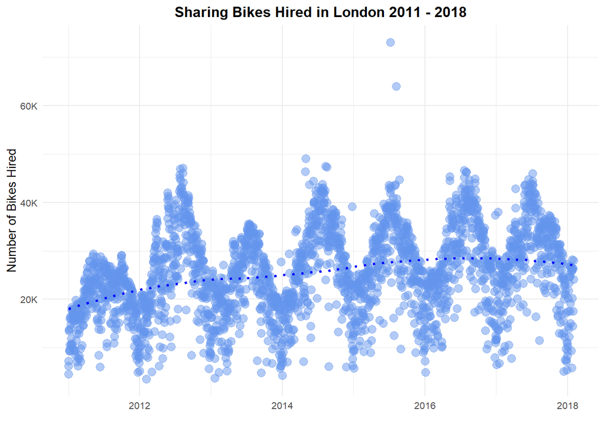

```r
ggplot(bike_data, aes(x = Day, y = bikes_hired)) +
  geom_point(color = "cornflowerblue", size = 3, alpha = 0.5) +
  geom_smooth(method = "loess", color = "blue", linetype = "dotted", se = FALSE) +
  labs(
    title = "Sharing Bikes Hired in London 2011 - 2018",
    x = "",
    y = "Number of Bikes Hired")  +
  scale_y_continuous(labels = label_number(scale = 1e-3, suffix = "K")) +
  theme_minimal(base_size = 10) +
  theme(
    plot.title = element_text(hjust = 0.5, face = "bold")
  )
```

The time series view allows a visual indication of existing intra and inter yearly factors influencing the number of bike hires. The figure above presents a cyclical pattern which repeats for each of the available years. Accompanied by an apparent slight increase in overall bike hiring across the captured timeframe. To further investigate these trends, the corresponding summary statistics are presented below.

## 3.2 Summary Statistics

### 3.2.1 Bikes Hired Overall

```r
favstats(~ bikes_hired, data= bike_data)
```

```
##   min       Q1  median       Q3   max     mean       sd    n missing
##  3531 19279.75 25285.5 31630.75 73094 25501.74 8813.388 2588     106
```

On average, the number of bikes hired on a single day is 25,501. However, the total number can vary from a minimum of 3,531 to a maximum of 73,094, accounting for an standard deviation of 8,813.

Given the data recorded spans across multiple years it is reasonable to encounter significant variability in the numbers. This can relate to both intra and inter year trends. Firstly, within a same year it is expected that bike hires will drop with lower temperatures (during late Autumn and Winter). Similarly, hires are expected to increase during Spring (when temperatures are leveled) and Summer (when the vacation season is at its peak). Secondly, across years, it is possible to see variance related to the hire programme characterisics. For instance, an increase in bike availability, a change in prices or a change in terms and conditions for the use of bikes.

### 3.2.2 Bikes Hired per Year

```r
favstats(~ bikes_hired | year, data=bike_data)
```

```
##   year  min    Q1  median       Q3   max     mean       sd   n missing
## 1 2011 4555 16260 20264.0 23708.00 29417 19568.35 5497.469 365       0
## 2 2012 3531 19282 26178.5 32532.75 47102 26008.97 9429.395 366       0
## 3 2013 3728 17555 22021.0 27371.00 35580 22042.35 7276.488 365       0
## 4 2014 4327 20532 27676.0 34437.00 49025 27462.73 9065.086 365       0
## 5 2015 5779 22056 26618.0 32857.00 73094 27046.13 8547.890 365       0
## 6 2016 4894 22402 27881.5 35130.00 46625 28152.01 8850.958 366       0
## 7 2017 5143 24064 29490.0 34459.00 46035 28619.30 8376.552 365       0
## 8 2018 5859 16291 23374.0 26354.00 28189 20835.52 6319.137  31      78
```

As suggested by the time series graph, the total number of bikes hired per year has been increasing from 2011 to 2018, with a single dip during 2013 of aproximately 4,000 hires. This deep corresponds to a significant increase in riding costs introduce on January 2013. When the 24-hour access increased in price from GBP1 to GBP2.

### 3.2.3 Bikes Hired per Season

```r
favstats(~ bikes_hired | season, data=bike_data)
```

```
##   season  min       Q1  median      Q3   max     mean       sd   n missing
## 1 Winter 3531 13679.25 18812.5 23184.0 39145 18286.79 6339.469 656       0
## 2 Spring 5249 22234.50 27491.5 32019.5 49025 27197.57 7517.420 644       0
## 3 Summer 4826 26594.50 33207.5 38181.0 73094 32261.40 8054.570 644       0
## 4 Autumn 5143 19391.25 24395.0 29373.5 40646 24395.65 6871.032 644       0
```

Similarly, as highlighted by the time series figure, Winter and Autumn record the lowest number of bike hires, while Summer and Spring record the highest. Interestingly Summer is the highest despite the high temperatures, which may point towards the vacationing period and increased number of events in and around the London parks.

### 3.2.4 Bikes Hired per Month

```r
favstats(~ bikes_hired | month, data=bike_data)
```

```
##    month   min       Q1  median       Q3   max     mean       sd   n missing
## 1      1  3728 13672.25 18016.5 22441.25 38042 17787.67 5864.386 248       0
## 2      2  3531 14917.75 19372.5 22785.50 29418 18611.69 5264.062 198       0
## 3      3  5062 18150.00 23069.0 26700.00 36539 22223.32 6566.820 217      31
## 4      4  6214 21321.25 25524.0 29597.00 49025 25268.95 6529.890 210      30
## 5      5 12049 23991.00 28730.0 33626.00 45301 28552.55 7059.705 217      17
## 6      6  6061 26364.75 31196.5 36648.25 44762 30785.81 7606.754 210       0
## 7      7 10224 28177.00 34704.0 39609.00 73094 33915.42 8085.127 217       0
## 8      8  6175 26910.00 33201.0 38134.00 63963 32076.02 8397.729 217       0
## 9      9  4826 25151.25 31490.0 35592.00 44909 30245.49 7081.533 210       0
## 10    10  7068 23663.00 27348.0 32552.00 37909 27428.66 5900.761 217       0
## 11    11  6030 18777.75 22494.0 27685.50 34747 22577.52 5923.925 210       0
## 12    12  4890 11684.00 17111.0 22940.00 39145 17268.18 6823.719 217       0
```

In accordance with the season overview above, the monthly breakdown support a cyclical yearly pattern closely tied to the change in seasons.

### 3.2.5 Bikes Hired per Day of the Week

```r
favstats(~ bikes_hired | day_of_week, data=bike_data)
```

```
##   day_of_week  min       Q1  median       Q3   max     mean       sd   n
## 1      Monday 6175 20369.25 24966.0 30876.75 43497 25517.52 7726.769 370
## 2     Tuesday 6201 22048.50 26850.5 33323.50 46625 27529.79 7812.573 370
## 3   Wednesday 4327 22471.00 27077.0 33526.00 49025 27750.59 7808.219 370
## 4    Thursday 7666 22210.00 26826.0 33574.00 73094 27826.70 8351.474 369
## 5      Friday 6900 21405.00 26155.0 32522.00 47102 26620.00 7797.571 369
## 6    Saturday 4555 15168.50 20483.5 29120.75 47454 22214.21 9554.213 370
## 7      Sunday 3531 13406.25 19388.5 28767.50 46276 21062.70 9743.700 370
##   missing
## 1      11
## 2      11
## 3      11
## 4      12
## 5      11
## 6      11
## 7      11
```

Lastly, when reviewing the data from a daily point of view, the results show that bike hires are highest during the week days. This suggests Londoners are keen on using the bike hire scheme for work commute. This insight is fundamental when deciding which new bike hire locations to introduce. Although bikes are also used for recreation (as showed by the still high number of hires during the weekend), the main target remains office commute.

## 3.3 Box Plots

Leveraging box plots, we can delve into further details of seasonal, monthly and week-day trends for bike hires.

```r
# Defines a function to plot the required box plots
gg_boxplot <- function(data, x, y, title) {

  # Evaluates variable names dynamically
  x <- rlang::ensym(x)
  y <- rlang::ensym(y)

  ggplot(data = data, aes(x = as.factor(!!x), y = !!y, fill = as.factor(!!x))) +
  geom_boxplot(outlier.color = "blue", outlier.shape = 19, outlier.size = 2) +
  scale_y_continuous(labels = label_number(scale = 1e-3, suffix = "K")) +
  labs(
    title = title,
    x = "",
    y = "Number of Bikes Hired"
  ) +
  scale_fill_brewer(palette = "Blues") +
  theme_minimal(base_size = 10) +
  theme(
    plot.title = element_text(hjust = 0.5, face = "bold"),
    legend.position = "none"
  )

}
```

### 3.3.1 Bikes Hired per Season

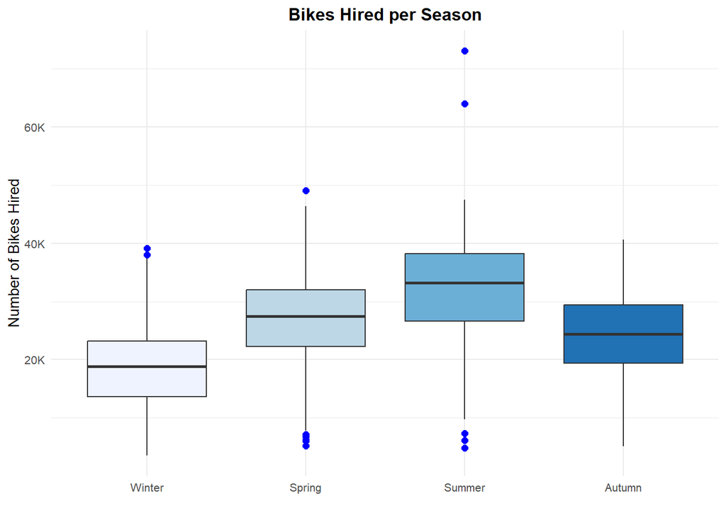

```r
# Filter out NA category
bike_data_filter_season <- bike_data %>%
  filter(!is.na(season))

# Box Plot
gg_boxplot(bike_data_filter_season, season, bikes_hired, "Bikes Hired per Season")
```

### 3.3.2 Bikes Hired per Month

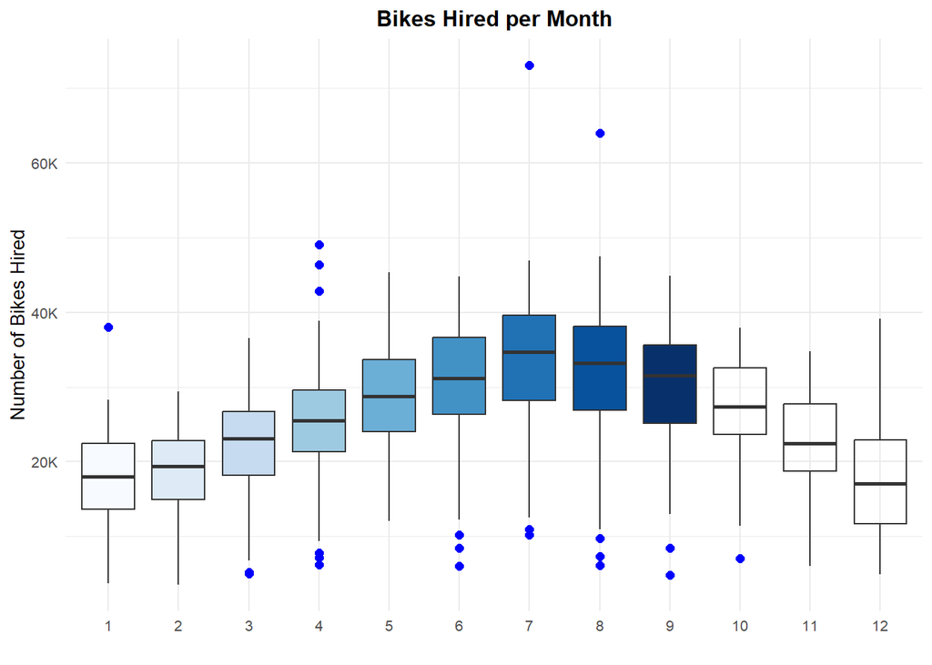

```r
# Filter out NA category
bike_data_filter_month <- bike_data %>%
  filter(!is.na(month))

# Box Plot
gg_boxplot(bike_data_filter_month, month, bikes_hired, "Bikes Hired per Month")
```

### 3.3.3 Bikes Hired per Day of the Week

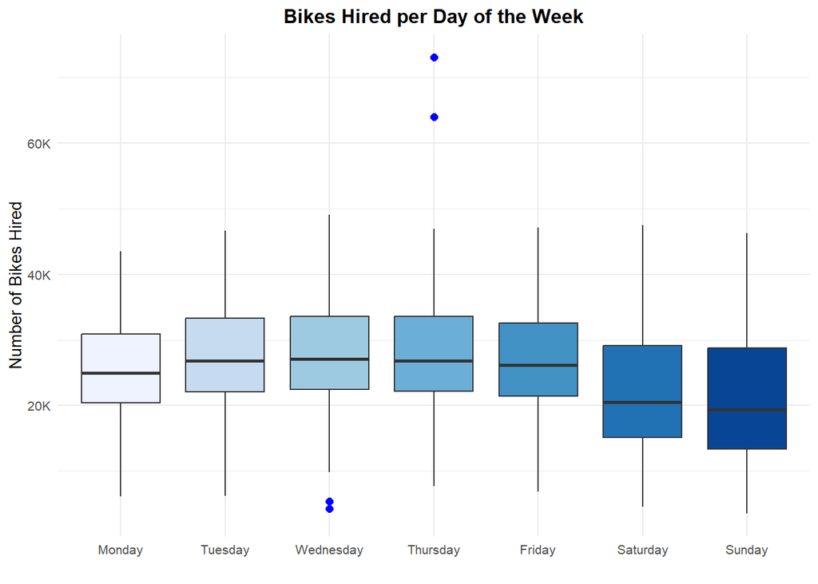

```r
# Filter out NA category
bike_data_filter_day_week <- bike_data %>%
  filter(!is.na(day_of_week))

# Box Plot
gg_boxplot(bike_data_filter_day_week, day_of_week, bikes_hired, "Bikes Hired per Day of the Week")
```

The box plots above allow the identification of potential outliers across the data while further confirming the cyclical trends present in bike hires across the year. For the weekly view, the boxplot further illustrates that within the work week the days with the highest mean number of hires are Tuesday through Thursday, with Friday slightly below and Monday further below. This trend is reasonable, and likely to be even more prevalent in the years following COVID-19 and hybrid work.

## 3.4 Min and Max

As an ad-hoc exercise it is interesting to identify the date with the maximum and minimum number of hires within the available data.

```r
# Max
max_date <- bike_data$Day[which.max(bike_data$bikes_hired)]
max_num <- max(bike_data$bikes_hired, na.rm = TRUE)

# Min
min_date <- bike_data$Day[which.min(bike_data$bikes_hired)]
min_num <- min(bike_data$bikes_hired, na.rm = TRUE)

cat("The date with the maximum number of hires was ", format(max_date, "%Y-%m-%d"), " with ", max_num, " total hires. \n")
```

```
## The date with the maximum number of hires was  2015-07-09  with  73094  total hires.
```

```r
cat("The date with the minimum number of hires was ", format(min_date, "%Y-%m-%d"), " with ", min_num, " total hires")
```

```
## The date with the minimum number of hires was  2012-02-05  with  3531  total hires
```

## 3.5 Density Plot: Bikes Hired per Season

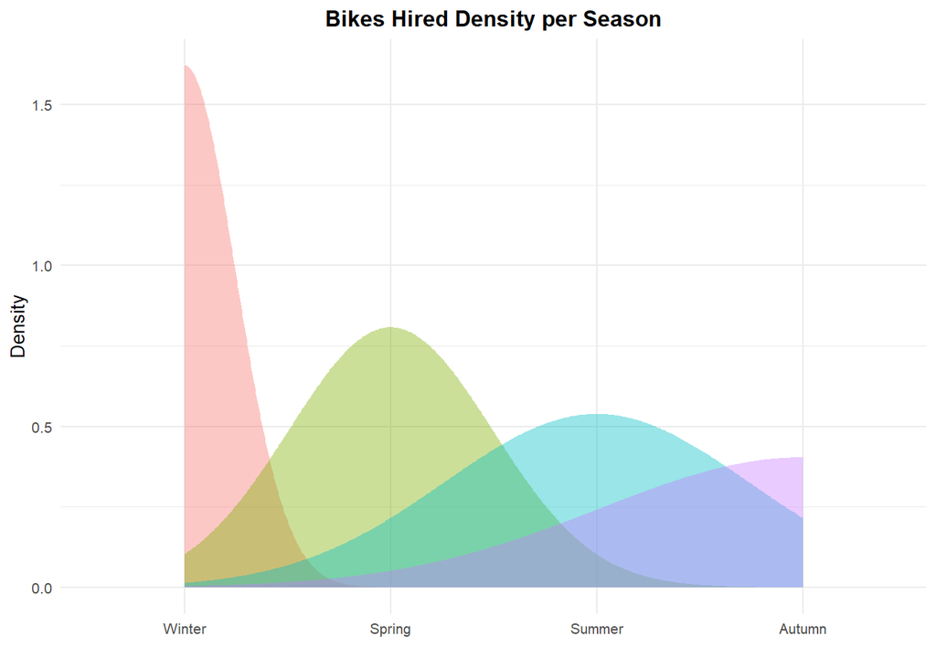

```r
ggplot(data = bike_data_filter_season, aes(x = season, fill = season)) +
  geom_density(alpha = 0.4, color = NA) +
  labs(
    title = "Bikes Hired Density per Season",
    x = "",
    y = "Density"
  ) +
  theme_minimal(base_size = 10) +
  theme(
    plot.title = element_text(hjust = 0.5, face = "bold"),
    legend.position = "none"
  )
```

## 3.6 Confidence Intervals

### 3.6.1 Winter and Summer

```r
data_summer <- bike_data %>%
  filter(season == "Summer") %>%
  select(bikes_hired)

result_summer <- t.test(data_summer)
result_summer <- result_summer$conf.int

data_winter <- bike_data %>%
  filter(season == "Winter") %>%
  select(bikes_hired)

result_winter <- t.test(data_winter)
result_winter <- result_winter$conf.int

cat("When calculating the 95% confidence intervals for the average number of bikes hired in Summer and Winter we get: \n Summer [", result_summer, "].\n Winter [", result_winter, "].")
```

```
## When calculating the 95% confidence intervals for the average number of bikes hired in Summer and Winter we get:
##  Summer [ 31638.14 32884.65 ].
##  Winter [ 17800.78 18772.81 ].
```

Meaning we are 95% sure that the true average number of bikes hired either in Summer or Winter are within the corresponding confidence interval. Therefore, analysing the lower and upper bounds of both confidence intervals (they do not intersect and any point) we could conclude, with 95% confidence, that there is a significant difference between the number of bikes hired in Winter and Summer.

### 3.6.2 Spring and Autumn

```r
data_spring <- bike_data %>%
  filter(season == "Spring") %>%
  select(bikes_hired)

result_spring <- t.test(data_spring)
result_spring <- result_spring$conf.int

data_autumn <- bike_data %>%
  filter(season == "Autumn") %>%
  select(bikes_hired)

result_autumn <- t.test(data_autumn)
result_autumn <- result_autumn$conf.int

cat("When calculating the 95% confidence intervals for the average number of bikes hired in Spring and Autumn we get: \n Spring [", result_spring, "].\n Autumn [", result_autumn, "].")
```

```
## When calculating the 95% confidence intervals for the average number of bikes hired in Spring and Autumn we get:
##  Spring [ 26615.88 27779.26 ].
##  Autumn [ 23863.98 24927.32 ].
```

Meaning we are 95% sure that the true average number of bikes hired either in Spring or Autumn are within the corresponding confidence interval. Therefore, analysing the lower and upper bounds of both confidence intervals (they do not intersect at any point) we could conclude, with 95% confidence, that there is a significant difference between the number of bikes hired in Spring and Autumn.

## 3.7 The Effect of Weather

The data frame has a number of variables related to weather. Including numerical records for `avg_temp`, `avg_humidity`, `avg_pressure`, and `avg_windspeed`. As well as binary records for `rain`, `fog`, `thunderstorm`, and `snow`.

Below a visual analysis of the effect of weather variables in the number of bikes hired.

```r
# Defines a function to plot the required scatter plots

gg_scatterplot <- function(x, xlabel, title) {

  # Evaluates variable names dynamically
  x <- rlang::ensym(x)

  # Data Filter

  bike_data_filtered <- bike_data %>%
  filter(!is.na(!!x))

  # Scatter plot

  ggplot(bike_data_filtered, aes(x = !!x, y = bikes_hired)) +
    geom_point(color = "cornflowerblue", size = 3, alpha = 0.5) +
    geom_smooth(method = "loess", color = "blue", linetype = "dotted", se = FALSE) +
    labs(
      title = title,
      x = xlabel,
      y = "Number of Bikes Hired")  +
    scale_y_continuous(labels = label_number(scale = 1e-3, suffix = "K")) +
    theme_minimal(base_size = 10) +
    theme(
      plot.title = element_text(hjust = 0.5, face = "bold")
  )
}
```

### 3.7.1 Average Temperature

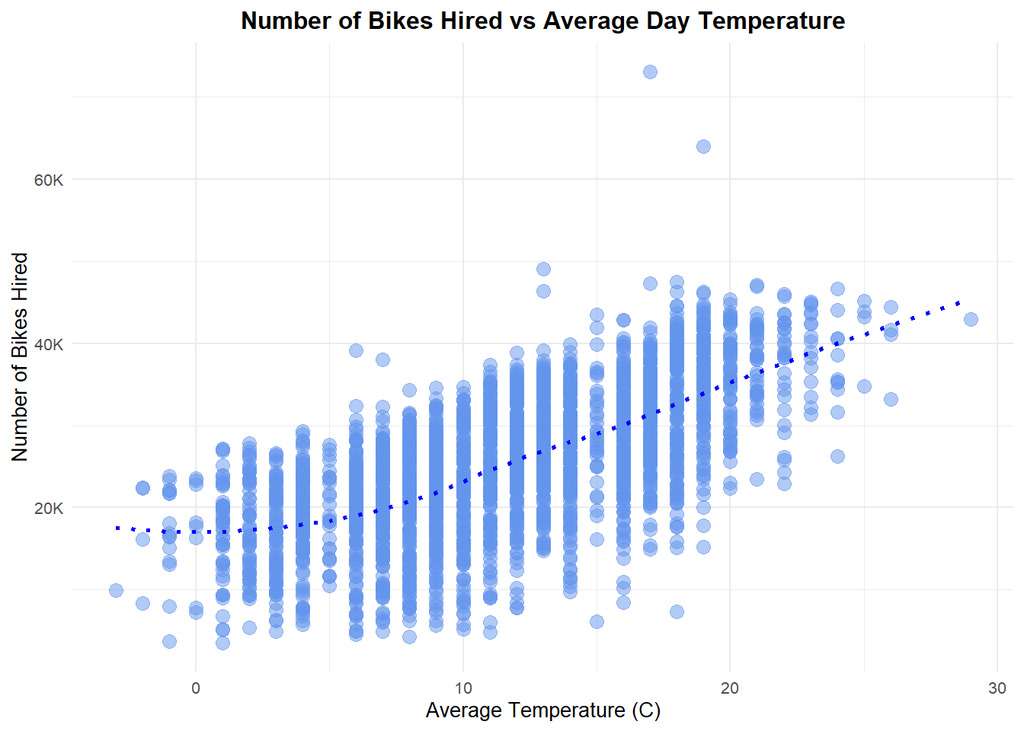

```r
gg_scatterplot(avg_temp, "Average Temperature (C)", "Number of Bikes Hired vs Average Day Temperature")
```

For the first case: temperature, there appears to be a positive relationship between the variables, meaning a higher temperature attracts more bike hires. However, this relationship is not perfect, in fact when temperature gets above 25 the number of observations reduce dramatically.

### 3.7.2 Average Humidity

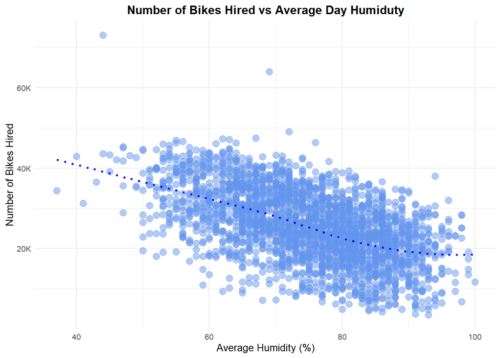

```r
gg_scatterplot(avg_humidity, "Average Humidity (%)", "Number of Bikes Hired vs Average Day Humiduty")
```

For the second case: humidity, the relationship between the variables seems to be negative. Meaning higher levels of humidity lead to lower numbers of bikes hired.

### 3.7.3 Average Pressure

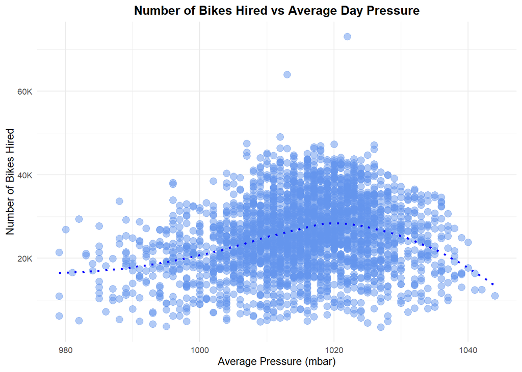

```r
gg_scatterplot(avg_pressure, "Average Pressure (mbar)", "Number of Bikes Hired vs Average Day Pressure")
```

### 3.7.4 Average Windpseed

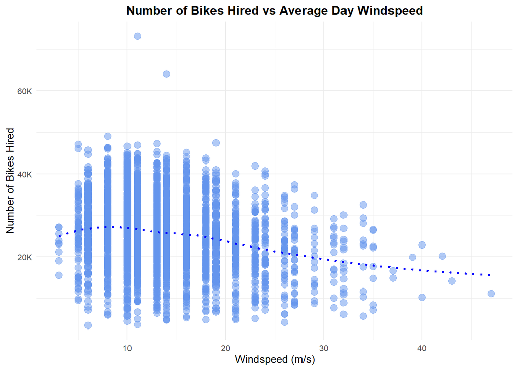

```r
gg_scatterplot(avg_windspeed, "Windspeed (m/s)", "Number of Bikes Hired vs Average Day Windspeed")
```

For the fourth case: wind speed, once again there is no clear relationship between the variables. Nonetheless, it is worth to mention that for wind speeds above 30 observations drop substantially.

Overall, results seem to follow people’s preferences logically; meaning people are more willing to ride a bike in a warm weather than in a cold one (given the temperature does not get extremely high) and they are also more willing to ride when humidity is low. On the other hand, pressure and wind speed cannot be as easily measured (or felt) as temperature and humidity, therefore, it is rarer for people to base their decision on those factors.

### 3.7.5 Rain

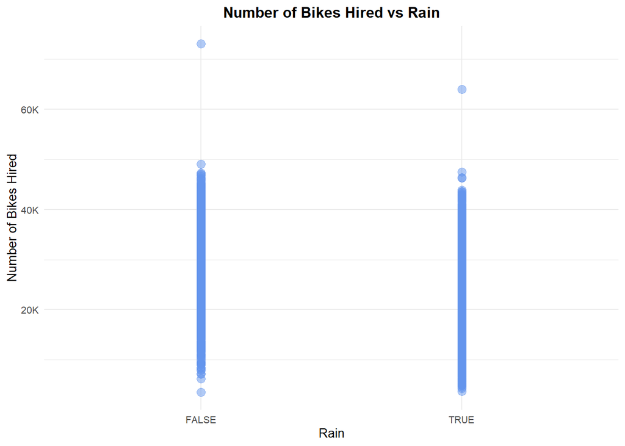

```r
gg_scatterplot(rain, "Rain" , "Number of Bikes Hired vs Rain")
```

### 3.7.6 Fog

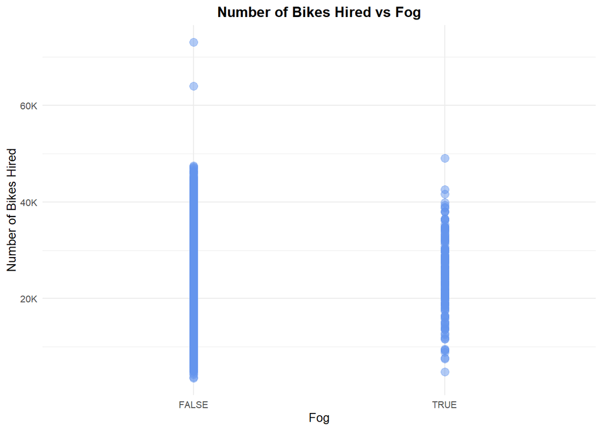

```r
gg_scatterplot(fog, "Fog", "Number of Bikes Hired vs Fog")
```

### 3.7.7 Thunderstorm

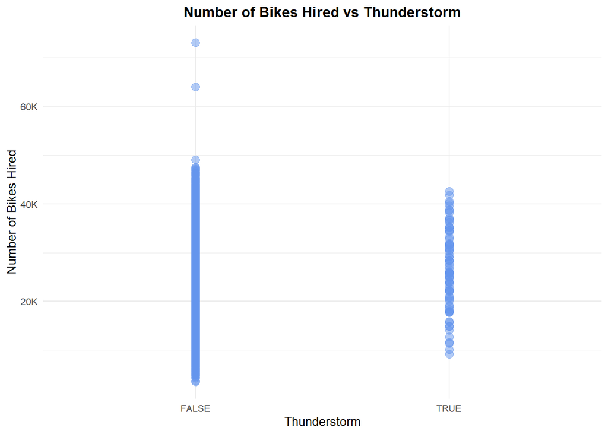

```r
gg_scatterplot(thunderstorm, "Thunderstorm", "Number of Bikes Hired vs Thunderstorm")
```

### 3.7.8 Snow

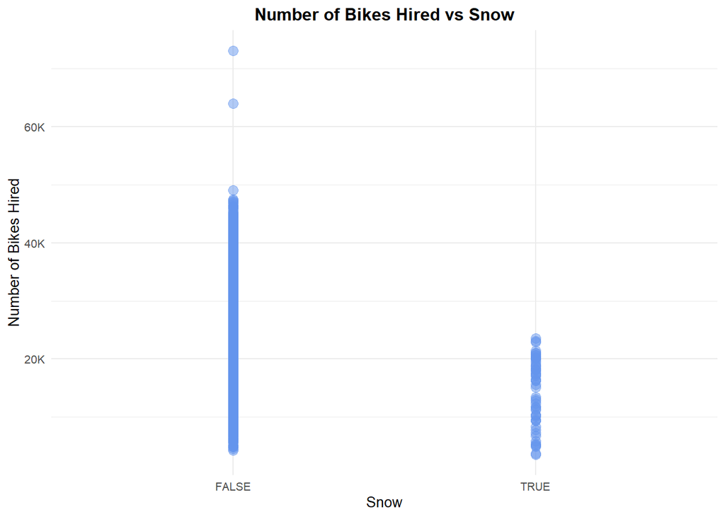

```r
gg_scatterplot(snow, "Snow", "Number of Bikes Hired vs Snow")
```

Moreover, concerning the remaining scenarios with categorical values, we can see that most cases also follow people’s preferences logically. People are less likely to hire bikes if there is snow, fog or thunder. With rain, however, the difference between rainy and dry days appears as not substantially significant. One explanation is that rain can be very unpredictable, and once people have rented a bike they will ride it whether it starts raining or not.